# Text Analytics

Ibrokhim Sadikov

September 20, 2019

```r
data <- fread("psychcentral_data.csv", sep=",", header=T, strip.white = T, na.strings = c("NA","NaN","","?"))
head(data, n=5)
```

```
##    row                                                 q_subject
## 1:   0                                    Saying Goodbye For Now
## 2:   1                       Im really afraid of going to school
## 3:   2                                    jealousy filled hatred
## 4:   3                     Is my friend stuck in a fantasy world
## 5:   4 I have mind problems or something weird pls read and help
##                                                                                                                                                                                                                                                                                                          …
## 1:                                                                                                                                                                                                                                                                                                       …
## 2:                                                                                                                                                                                                                                                                                                       …
## 3:                                                                                                                                                                                                                                                                                                       …
## 4:                                                                                                                                                                                                                                                                                                       …
## 5: nSorry for my English not my speaking language I will tell you the full story So basically for the last few days I feel different Its like I cant think straight my mind isnt clear and stuff like that I wouldnt even call it depression or anxietyeven tho at 1st I thought that it is something lik…
##                                                                                                                                                                                                                                                                                                          …
## 1:                                                                                                                                                                                                                                                                                                       …
## 2: Hi shybookworm12  Im really sorry youre feeling upset and anxious Although Im older than you I can relate to feeling anxious about returning to school because I was very shy I wasnt bullied but can understand how this makes school seem scary Its also wrong for your family to joke or make criti…
## 3:                                                                                                                                                                                                                                                                                                       …
## 4:                                                                                                                                                                                                                                                                                                       …
## 5:                                                                                                                                                                                                                                                                                                       …
```

## 3.1. (1 point) What are the column names in the data?

## 3.2. (1 point) How many rows does this data have?

```r
colnames(data)
```

```
## [1] "row"       "q_subject" "q_content" "answers"
```

```r
nrow(data)
```

```
## [1] 8360
```

## 4. Using libraries dplyr and tidytext, we will tokenize column q_content.

```r
tidy_text<-data %>%
  unnest_tokens(word, q_content)
tidy_text[1:15]
```

```
##     row              q_subject answers     word
##  1:   0 Saying Goodbye For Now    <NA>     nits
##  2:   0 Saying Goodbye For Now    <NA>     been
##  3:   0 Saying Goodbye For Now    <NA>        a
##  4:   0 Saying Goodbye For Now    <NA> pleasure
##  5:   0 Saying Goodbye For Now    <NA>  hosting
##  6:   0 Saying Goodbye For Now    <NA>     this
##  7:   0 Saying Goodbye For Now    <NA>  service
##  8:   0 Saying Goodbye For Now    <NA>     over
##  9:   0 Saying Goodbye For Now    <NA>      the
## 10:   0 Saying Goodbye For Now    <NA>     past
## 11:   0 Saying Goodbye For Now    <NA>    three
## 12:   0 Saying Goodbye For Now    <NA>    years
## 13:   0 Saying Goodbye For Now    <NA>       at
## 14:   0 Saying Goodbye For Now    <NA>    psych
## 15:   0 Saying Goodbye For Now    <NA>  central
```

## Now we remove the stop-words.

```r
data(stop_words)

tidy_text <- tidy_text %>%
  anti_join(stop_words)
```

## Now we are counting the number of tokens.

```r
tidy_text %>%
  count(word, sort = TRUE)
```

```
## # A tibble: 46,081 x 2
##    word        n
##    <chr>   <int>
##  1 im      13012
##  2 dont    11197
##  3 feel     9168
##  4 time     6697
##  5 life     4464
##  6 ive      4403
##  7 people   4233
##  8 told     4150
##  9 friends  4045
## 10 love     3281
## # ... with 46,071 more rows
```

## What are the top five tokens returned?

## -im

## -dont

## -feel

## -time

## -life

## Using library ggplot2 we will create a visualization that shows the frequency of the tokens that appeared for at least 2000 times. the visualization is below:

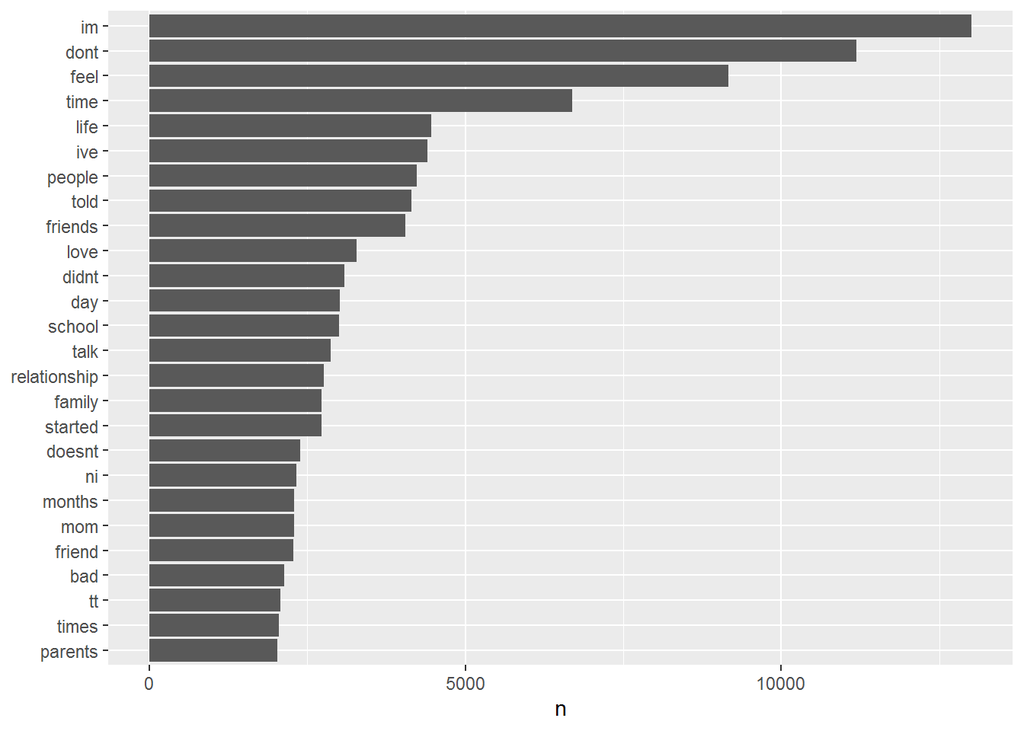

```r
tidy_text %>%
  count(word, sort = TRUE) %>%
  filter(n > 2000) %>%
  mutate(word = reorder(word, n)) %>%
  ggplot(aes(word, n)) +
  geom_bar(stat='identity') +
  xlab(NULL) +
  coord_flip()
```

## Based on the results in 4.2., would you suggest stemming on this text? Why? Bring one example from the visualization above that shows stemming should be done on this text?

*-friend vs friends: I would suggest stemming as example above shows both of these words has the same root and thus appearing them twice brings extra redundancy.*

## Installing SnowballC package using install.packages(“SnowballC”, repos = “https://cran.r-project.org”). Use library SnowballC to stem q_content using the code below

```r
library(SnowballC)
tidy_text <- data %>%
    unnest_tokens(word, q_content) %>%
mutate(word = wordStem(word))
```

## Now we remove the stop-words.

```r
 data(stop_words)

tidy_text <- tidy_text %>%
  anti_join(stop_words)
 tidy_text %>%
  count(word, sort = TRUE)
```

```
## # A tibble: 36,404 x 2
##    word       n
##    <chr>  <int>
##  1 wa     21437
##  2 thi    14961
##  3 im     13016
##  4 feel   12905
##  5 dont   11197
##  6 time    8755
##  7 becaus  8104
##  8 ha      7340
##  9 realli  6780
## 10 thei    6698
## # ... with 36,394 more rows
```

## what are the top five tokens after stemming?

## -wa

## -thi

## -im

## -feel

## -dont

## Using library ggplot2 we will create a visualization that shows the frequency of the tokens that appeared for at least 4000 times.

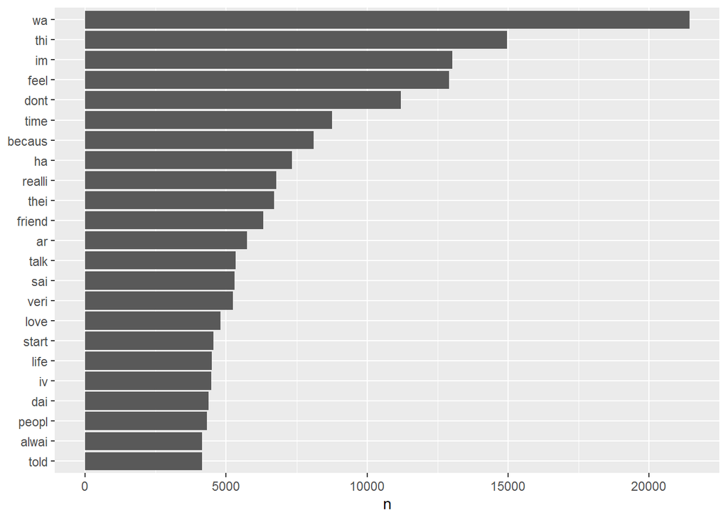

```r
 tidy_text %>%
  count(word, sort = TRUE) %>%
  filter(n > 4000) %>%
  mutate(word = reorder(word, n)) %>%
  ggplot(aes(word, n)) +
  geom_bar(stat='identity') +
  xlab(NULL) +
  coord_flip()
```

## Using library wordcloud we will create a word cloud with the 200 most used tokens. The visualization is below:

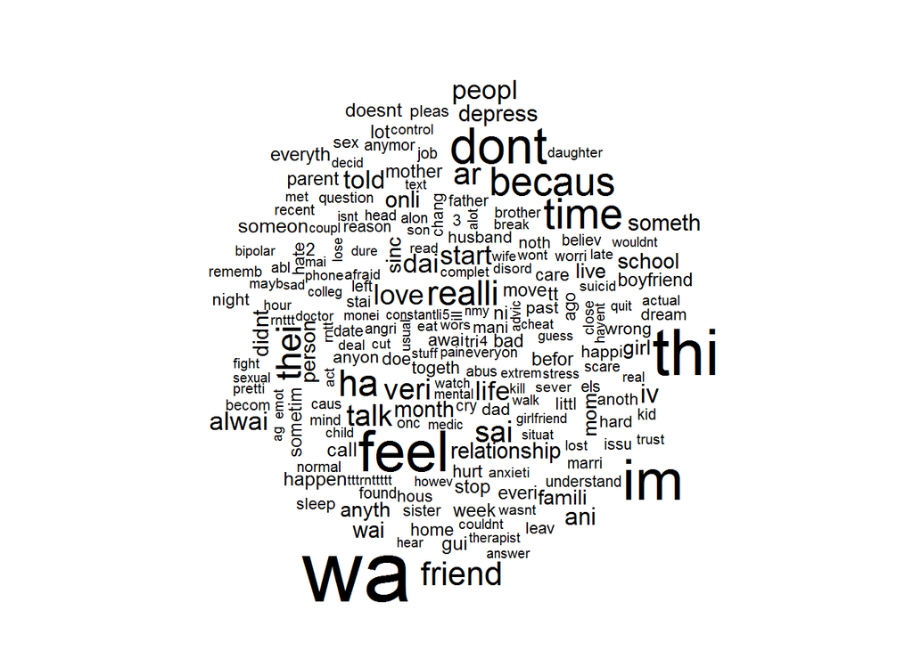

```r
tidy_text %>%
  anti_join(stop_words) %>%
  count(word) %>%
  with(wordcloud(word, n, max.words = 200))
```

## Creating a color-coded word cloud based on sentiment. Using the most frequent 100 tokens for positive and negative words. The word cloud is in the space below:

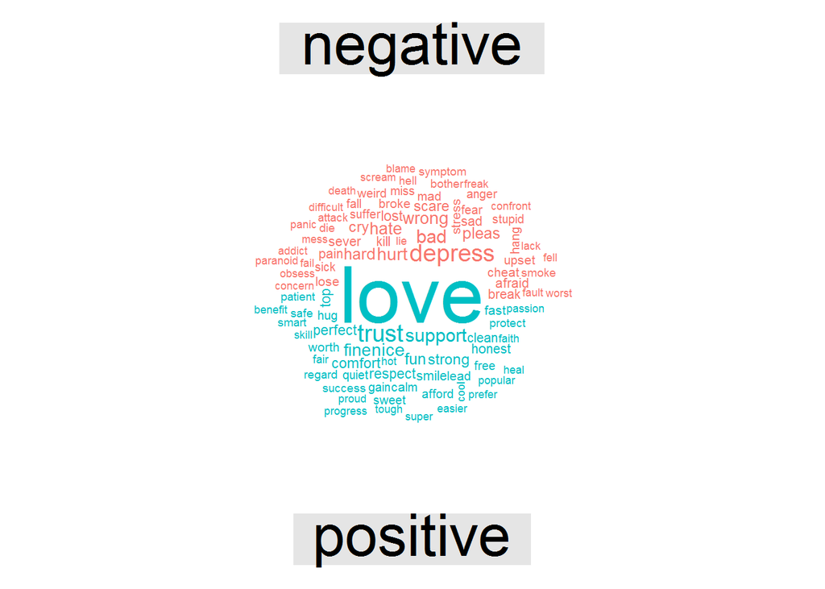

```r
tidy_text %>%
  inner_join(get_sentiments("bing")) %>%
  count(word, sentiment, sort = TRUE) %>%
  acast(word ~ sentiment, value.var = "n", fill = 0) %>%
  comparison.cloud(colors = c("#F8766D", "#00BFC4"),
                   max.words = 100)
```

## Repeating all the steps in question 4 but this time for column answers.

```r
 tidy_text2<-data %>%
  unnest_tokens(word, answers)
tidy_text2[1:15]
```

```
##     row                           q_subject
##  1:   0              Saying Goodbye For Now
##  2:   1 Im really afraid of going to school
##  3:   1 Im really afraid of going to school
##  4:   1 Im really afraid of going to school
##  5:   1 Im really afraid of going to school
##  6:   1 Im really afraid of going to school
##  7:   1 Im really afraid of going to school
##  8:   1 Im really afraid of going to school
##  9:   1 Im really afraid of going to school
## 10:   1 Im really afraid of going to school
## 11:   1 Im really afraid of going to school
## 12:   1 Im really afraid of going to school
## 13:   1 Im really afraid of going to school
## 14:   1 Im really afraid of going to school
```

[output cut: 33 more lines]

```r
 data(stop_words)

tidy_text2 <- tidy_text2 %>%
  anti_join(stop_words)
 tidy_text2 %>%
  count(word, sort = TRUE)
```

```
## # A tibble: 54,645 x 2
##    word             n
##    <chr>        <int>
##  1 dont         18010
##  2 feel         13279
##  3 people       10334
##  4 youre        10162
##  5 time          9729
##  6 im            9664
##  7 life          9169
##  8 ni            8913
##  9 talk          6245
## 10 relationship  5557
## # ... with 54,635 more rows
```

## What are the top five tokens returned?

## -dont

## -feel

## -people

## -youre

## -time

## Using library ggplot2 we will create a visualization that shows the frequency of the tokens that appeared for at least 4000 times. The visualization below:

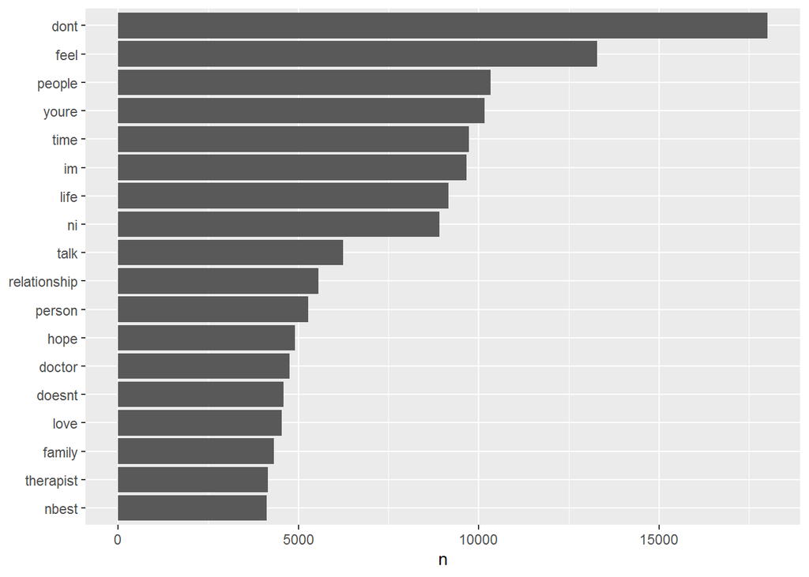

```r
  tidy_text2 %>%
  count(word, sort = TRUE) %>%
  filter(n > 4000) %>%
  mutate(word = reorder(word, n)) %>%
  ggplot(aes(word, n)) +
  geom_bar(stat='identity') +
  xlab(NULL) +
  coord_flip()
```

## Stemming for ‘answers’ column

```r
tidy_text2 <- data %>%
    unnest_tokens(word, answers) %>%
mutate(word = wordStem(word))
```

```r
 data(stop_words)

tidy_text2 <- tidy_text2 %>%
  anti_join(stop_words)
 tidy_text2 %>%
  count(word, sort = TRUE)
```

```
## # A tibble: 42,210 x 2
##    word       n
##    <chr>  <int>
##  1 thi    31989
##  2 ar     29063
##  3 feel   21550
##  4 dont   18011
##  5 wa     14041
##  6 thei   13587
##  7 time   11661
##  8 peopl  10537
##  9 becaus  9834
## 10 wai     9797
## # ... with 42,200 more rows
```

## Now what are the top five tokens after stemming?

## -thi

## -ar

## -feel

## -dont

## -wa

## Using library ggplot2 we will create a visualization that shows the frequency of the tokens that appeared for at least 6000 times. The visualization below:

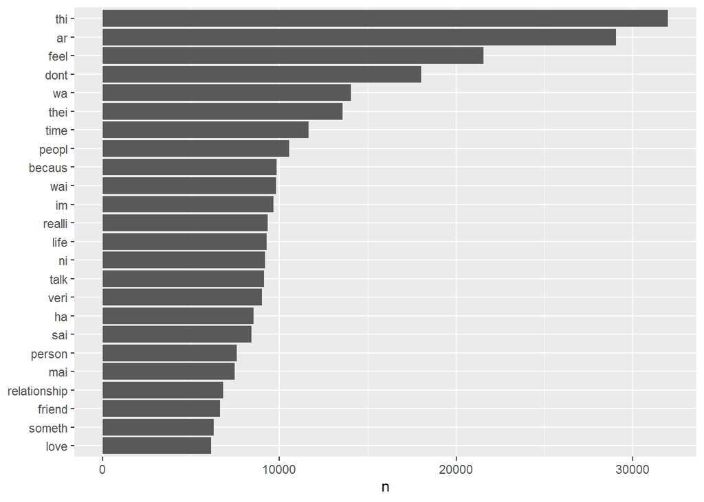

```r
 tidy_text2 %>%
  count(word, sort = TRUE) %>%
  filter(n > 6000) %>%
  mutate(word = reorder(word, n)) %>%
  ggplot(aes(word, n)) +
  geom_bar(stat='identity') +
  xlab(NULL) +
  coord_flip()
```

## Using library wordcloud we will create a word cloud with the 200 most used tokens. Paste the visualization below:

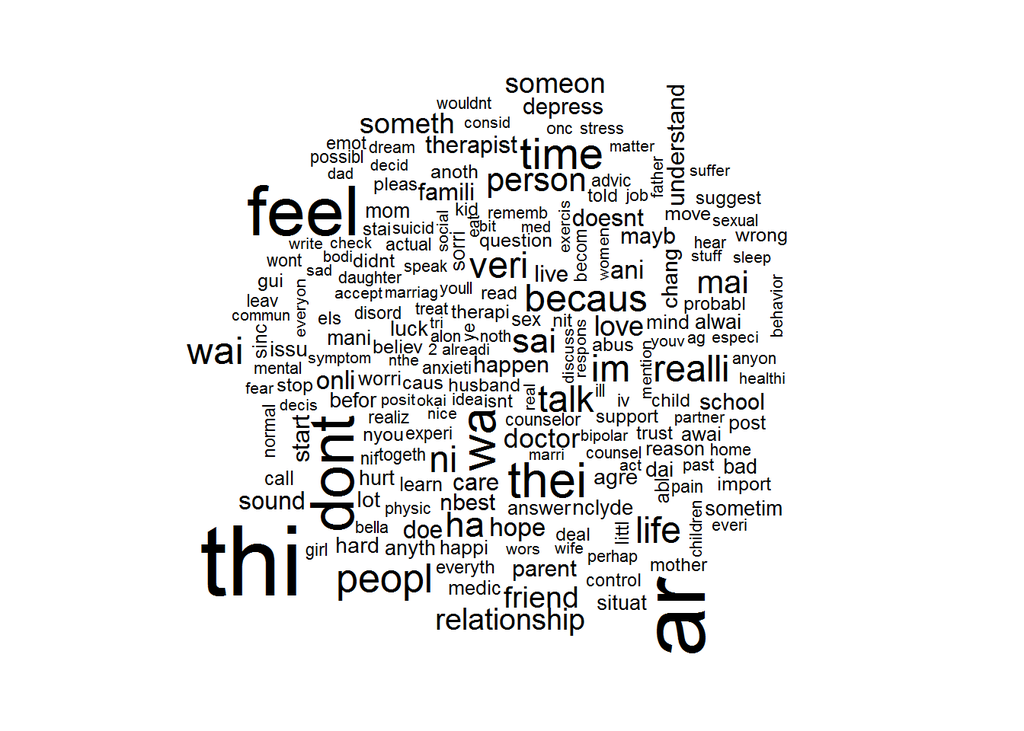

```r
 tidy_text2 %>%
  anti_join(stop_words) %>%
  count(word) %>%
  with(wordcloud(word, n, max.words = 200))
```

## Creating a color-coded word cloud based on sentiment. Using the most frequent 100 tokens for positive and negative words. The word cloud in the space below:

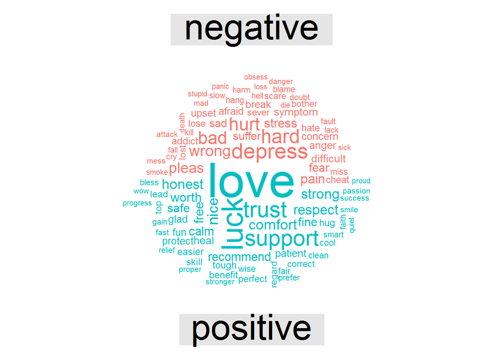

```r
 tidy_text2 %>%
  inner_join(get_sentiments("bing")) %>%
  count(word, sentiment, sort = TRUE) %>%
  acast(word ~ sentiment, value.var = "n", fill = 0) %>%
  comparison.cloud(colors = c("#F8766D", "#00BFC4"),
                   max.words = 100)
```

# Topic MOdelling

### Performing topic-modeling on q_content

```r
 data <- data[1:1000,] # We perform LDA on the rows 1 through 1000 in the data.
corpus <- Corpus(VectorSource(data$q_content), readerControl=list(language="en"))
dtm <- DocumentTermMatrix(corpus, control = list(stopwords = TRUE, minWordLength = 2, removeNumbers = TRUE, removePunctuation = TRUE,  stemDocument = TRUE))
rowTotals <- apply(dtm , 1, sum) #Find the sum of words in each Document
dtm.new   <- dtm[rowTotals> 0, ] #remove all docs without words
lda <- LDA(dtm.new, k = 5) # k is the number of topics to be found.
```

## The code above will create the beta scores for each document per topic (k = 5). Then create bar plots (similar to what we created in class) for each topic for 10 tokens (top_n(10, beta)). Paste the visualization below.

```r
library(dplyr)
lda_td <- tidy(lda)
lda_td
```

```
## # A tibble: 71,290 x 3
##    topic term         beta
##    <int> <chr>       <dbl>
##  1     1 aboven  1.11e- 24
##  2     2 aboven  6.27e-118
##  3     3 aboven  2.61e- 22
##  4     4 aboven  4.99e-  5
##  5     5 aboven  5.26e-  5
##  6     1 account 3.77e- 95
##  7     2 account 1.00e-  4
##  8     3 account 3.63e-  4
##  9     4 account 5.17e-  5
## 10     5 account 1.53e-  4
## # ... with 71,280 more rows
```

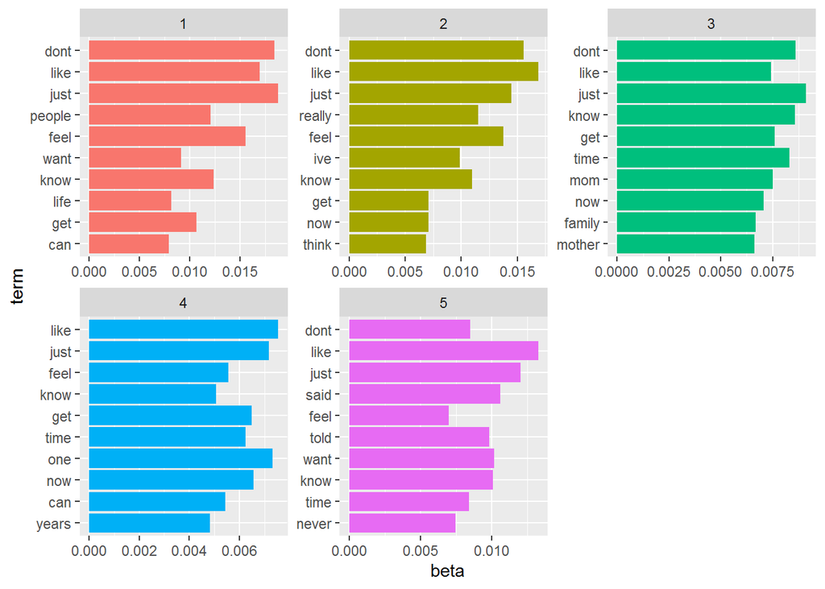

```r
top_terms <- lda_td %>%
  group_by(topic) %>%
  top_n(10, beta) %>%
  ungroup() %>%
  arrange(topic, -beta)

top_terms %>%
  mutate(term = reorder(term, beta)) %>%
  ggplot(aes(term, beta, fill = factor(topic))) +
  geom_bar(stat = "identity", show.legend = FALSE) +
  facet_wrap(~ topic, scales = "free") +
  coord_flip()
```

## 6.3.1. K = 2. Paste your visualization in the space below:

```r
 lda <- LDA(dtm.new, k = 2)
lda_td <- tidy(lda)
lda_td
```

```
## # A tibble: 28,516 x 3
##    topic term         beta
##    <int> <chr>       <dbl>
##  1     1 aboven   2.79e- 5
##  2     2 aboven   1.24e- 5
##  3     1 account  2.79e- 4
##  4     2 account  4.48e-14
##  5     1 actually 7.34e- 4
##  6     2 actually 1.44e- 3
##  7     1 advice   7.18e- 4
##  8     2 advice   6.65e- 4
##  9     1 already  6.24e- 4
## 10     2 already  5.25e- 4
## # ... with 28,506 more rows
```

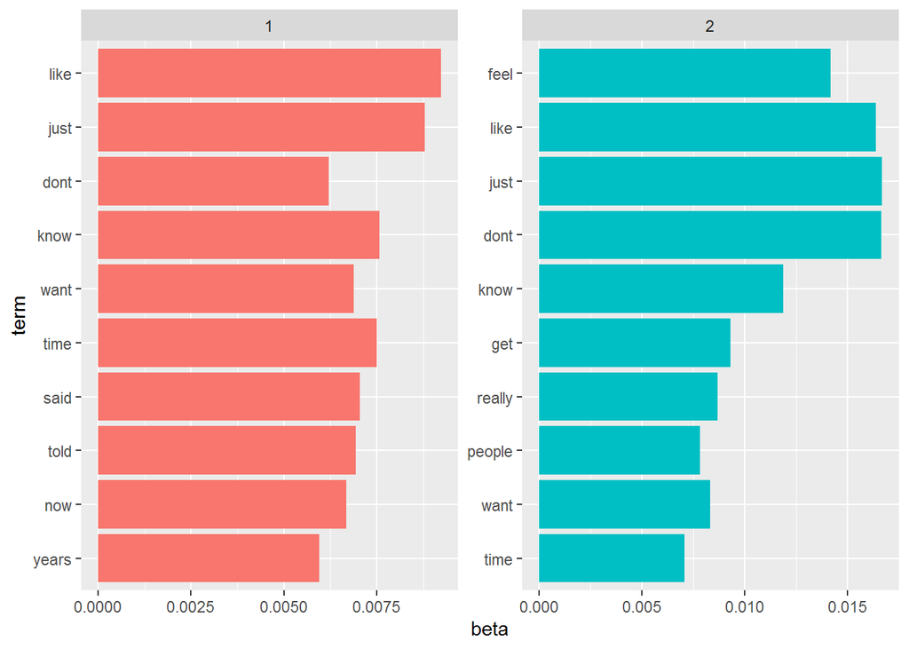

```r
top_terms <- lda_td %>%
  group_by(topic) %>%
  top_n(10, beta) %>%
  ungroup() %>%
  arrange(topic, -beta)

top_terms %>%
  mutate(term = reorder(term, beta)) %>%
  ggplot(aes(term, beta, fill = factor(topic))) +
  geom_bar(stat = "identity", show.legend = FALSE) +
  facet_wrap(~ topic, scales = "free") +
  coord_flip()
```

## K = 3. Paste your visualization in the space below:

```r
 lda <- LDA(dtm.new, k = 3)
lda_td <- tidy(lda)
lda_td
```

```
## # A tibble: 42,774 x 3
##    topic term         beta
##    <int> <chr>       <dbl>
##  1     1 aboven   1.80e- 5
##  2     2 aboven   6.71e-16
##  3     3 aboven   5.56e- 5
##  4     1 account  2.09e- 4
##  5     2 account  2.57e- 7
##  6     3 account  2.33e- 4
##  7     1 actually 9.84e- 4
##  8     2 actually 1.51e- 3
##  9     3 actually 6.21e- 4
## 10     1 advice   4.08e- 4
## # ... with 42,764 more rows
```

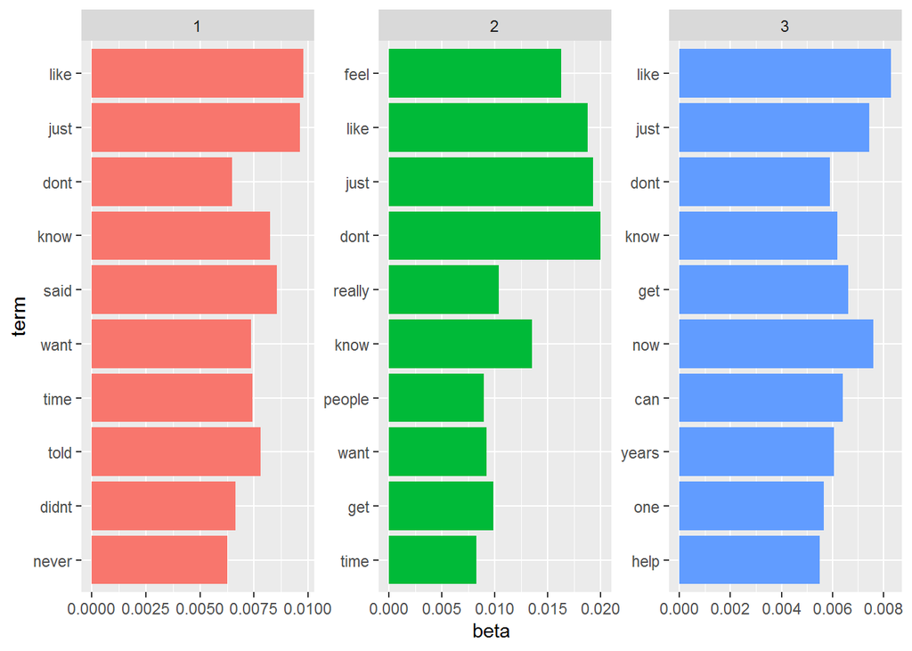

```r
top_terms <- lda_td %>%
  group_by(topic) %>%
  top_n(10, beta) %>%
  ungroup() %>%
  arrange(topic, -beta)

top_terms %>%
  mutate(term = reorder(term, beta)) %>%
  ggplot(aes(term, beta, fill = factor(topic))) +
  geom_bar(stat = "identity", show.legend = FALSE) +
  facet_wrap(~ topic, scales = "free") +
  coord_flip()
```

## K = 4. Paste your visualization in the space below:

```r
 lda <- LDA(dtm.new, k = 4)
lda_td <- tidy(lda)
lda_td
```

```
## # A tibble: 57,032 x 3
##    topic term         beta
##    <int> <chr>       <dbl>
##  1     1 aboven   2.28e- 5
##  2     2 aboven   3.11e- 5
##  3     3 aboven   8.11e-17
##  4     4 aboven   2.73e- 5
##  5     1 account  3.21e- 4
##  6     2 account  1.10e- 4
##  7     3 account  9.20e- 8
##  8     4 account  6.56e- 5
##  9     1 actually 1.01e- 3
## 10     2 actually 1.20e- 3
## # ... with 57,022 more rows
```

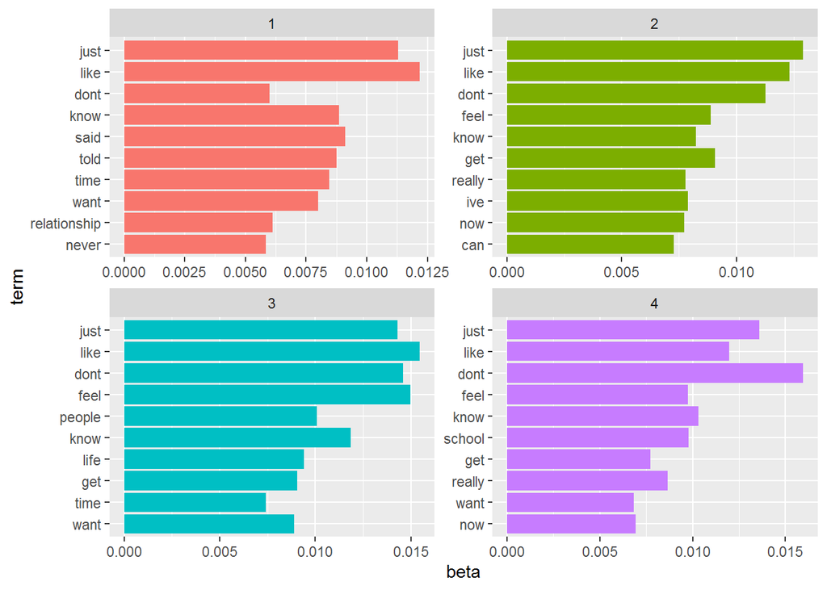

```r
top_terms <- lda_td %>%
  group_by(topic) %>%
  top_n(10, beta) %>%
  ungroup() %>%
  arrange(topic, -beta)

top_terms %>%
  mutate(term = reorder(term, beta)) %>%
  ggplot(aes(term, beta, fill = factor(topic))) +
  geom_bar(stat = "identity", show.legend = FALSE) +
  facet_wrap(~ topic, scales = "free") +
  coord_flip()
```

## K = 10. Paste your visualization in the space below:

```r
 lda <- LDA(dtm.new, k = 10)
lda_td <- tidy(lda)
lda_td
```

```
## # A tibble: 142,580 x 3
##    topic term        beta
##    <int> <chr>      <dbl>
##  1     1 aboven 1.73e-  4
##  2     2 aboven 9.93e-172
##  3     3 aboven 8.91e-  5
##  4     4 aboven 2.19e-172
##  5     5 aboven 1.56e-162
##  6     6 aboven 3.43e-169
##  7     7 aboven 8.69e-156
##  8     8 aboven 2.11e-  8
##  9     9 aboven 1.28e-151
## 10    10 aboven 9.16e- 10
## # ... with 142,570 more rows
```

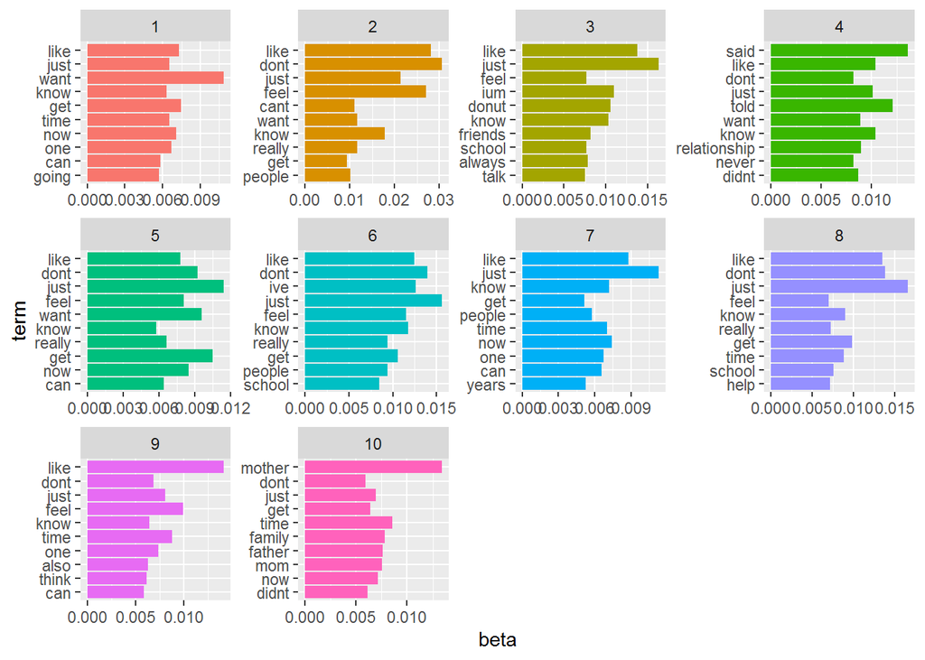

```r
top_terms <- lda_td %>%
  group_by(topic) %>%
  top_n(10, beta) %>%
  ungroup() %>%
  arrange(topic, -beta)

top_terms %>%
  mutate(term = reorder(term, beta)) %>%
  ggplot(aes(term, beta, fill = factor(topic))) +
  geom_bar(stat = "identity", show.legend = FALSE) +
  facet_wrap(~ topic, scales = "free") +
  coord_flip()
```

## 7. Using the following code to perform topic-modeling on ANSWER

```r
 data <- data[1:1000,] # We perform LDA on the rows 1 through 1000 in the data.
corpus <- Corpus(VectorSource(data$answers), readerControl=list(language="en"))
dtm <- DocumentTermMatrix(corpus, control = list(stopwords = TRUE, minWordLength = 2, removeNumbers = TRUE, removePunctuation = TRUE,  stemDocument = TRUE))
rowTotals <- apply(dtm , 1, sum) #Find the sum of words in each Document
dtm.new   <- dtm[rowTotals> 0, ] #remove all docs without words
lda <- LDA(dtm.new, k = 10) # k is the number of topics to be found.
```

## 7.1. (5 points) The code BELOW will create the beta scores for each document per topic (k = 10). Then create bar plots (similar to what we created in class) for each topic for 10 tokens (top_n(10, beta)). Paste the visualization below.

```r
library(dplyr)
lda_td <- tidy(lda)
lda_td
```

```
## # A tibble: 129,910 x 3
##    topic term        beta
##    <int> <chr>      <dbl>
##  1     1 actions 2.62e- 4
##  2     2 actions 3.10e- 4
##  3     3 actions 3.83e- 4
##  4     4 actions 7.08e- 5
##  5     5 actions 6.75e- 5
##  6     6 actions 9.67e- 5
##  7     7 actions 1.81e-14
##  8     8 actions 1.19e- 3
##  9     9 actions 3.32e- 4
## 10    10 actions 3.31e- 4
## # ... with 129,900 more rows
```

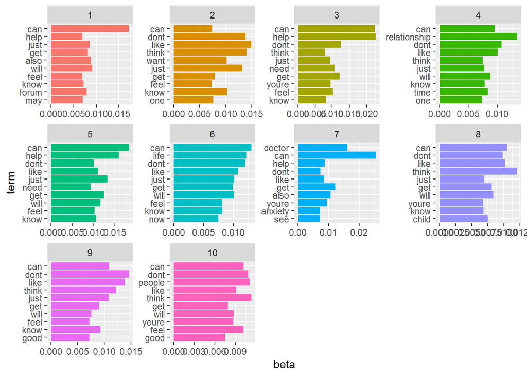

```r
top_terms <- lda_td %>%
  group_by(topic) %>%
  top_n(10, beta) %>%
  ungroup() %>%
  arrange(topic, -beta)

top_terms %>%
  mutate(term = reorder(term, beta)) %>%
  ggplot(aes(term, beta, fill = factor(topic))) +
  geom_bar(stat = "identity", show.legend = FALSE) +
  facet_wrap(~ topic, scales = "free") +
  coord_flip()
```

## 7.2. (5 points) Based on the visualization in 7.1., are the tokens in all topics similar? Then what can you say about k? Would you try a larger k or a smaller k?

*** It is difficult to decide from the first k. That is why we need to try different both smaller or larger ks’ to see and indetify clear differences. Above plot shows us topics almost with similar variations with introducing few topics***

## 7.3. (10 points) Repeat 7.1. with the following ks:

## 7.3.1. K = 2. Paste your visualization in the space below:

```r
 lda <- LDA(dtm.new, k = 2)
lda_td <- tidy(lda)
lda_td
```

```
## # A tibble: 25,982 x 3
##    topic term          beta
##    <int> <chr>        <dbl>
##  1     1 actions  0.000326
##  2     2 actions  0.000254
##  3     1 activity 0.0000965
##  4     2 activity 0.000133
##  5     1 advice   0.000556
##  6     2 advice   0.00179
##  7     1 affected 0.000195
##  8     2 affected 0.000108
##  9     1 also     0.00811
## 10     2 also     0.00436
## # ... with 25,972 more rows
```

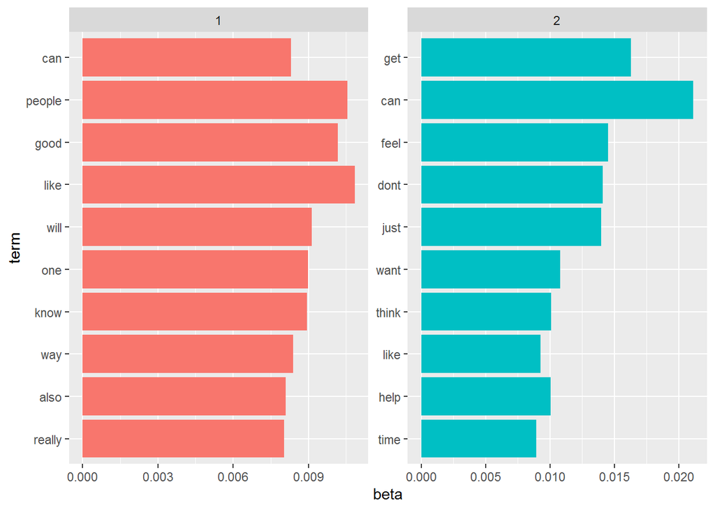

```r
top_terms <- lda_td %>%
  group_by(topic) %>%
  top_n(10, beta) %>%
  ungroup() %>%
  arrange(topic, -beta)

top_terms %>%
  mutate(term = reorder(term, beta)) %>%
  ggplot(aes(term, beta, fill = factor(topic))) +
  geom_bar(stat = "identity", show.legend = FALSE) +
  facet_wrap(~ topic, scales = "free") +
  coord_flip()
```

## 7.3.2. K = 8. Paste your visualization in the space below:

```r
 lda <- LDA(dtm.new, k = 8)
lda_td <- tidy(lda)
lda_td
```

```
## # A tibble: 103,928 x 3
##    topic term            beta
##    <int> <chr>          <dbl>
##  1     1 actions  0.000525
##  2     2 actions  0.000411
##  3     3 actions  0.000219
##  4     4 actions  0.0000135
##  5     5 actions  0.000308
##  6     6 actions  0.000721
##  7     7 actions  0.00000107
##  8     8 actions  0.000143
##  9     1 activity 0.000000186
## 10     2 activity 0.000253
## # ... with 103,918 more rows
```

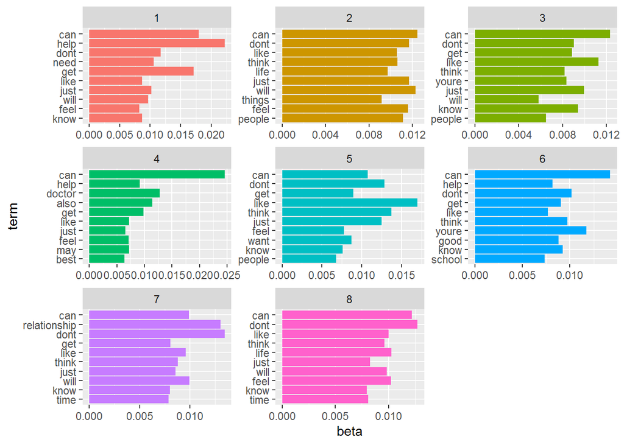

```r
top_terms <- lda_td %>%
  group_by(topic) %>%
  top_n(10, beta) %>%
  ungroup() %>%
  arrange(topic, -beta)

top_terms %>%
  mutate(term = reorder(term, beta)) %>%
  ggplot(aes(term, beta, fill = factor(topic))) +
  geom_bar(stat = "identity", show.legend = FALSE) +
  facet_wrap(~ topic, scales = "free") +
  coord_flip()
```

## 7.3.3. K = 11. Paste your visualization in the space below:

```r
 lda <- LDA(dtm.new, k = 11)
lda_td <- tidy(lda)
lda_td
```

```
## # A tibble: 142,901 x 3
##    topic term        beta
##    <int> <chr>      <dbl>
##  1     1 actions 6.21e- 4
##  2     2 actions 7.02e-20
##  3     3 actions 5.19e- 4
##  4     4 actions 3.80e- 4
##  5     5 actions 4.04e- 4
##  6     6 actions 1.68e- 4
##  7     7 actions 7.29e- 5
##  8     8 actions 4.90e- 4
##  9     9 actions 3.54e- 4
## 10    10 actions 1.37e-18
## # ... with 142,891 more rows
```

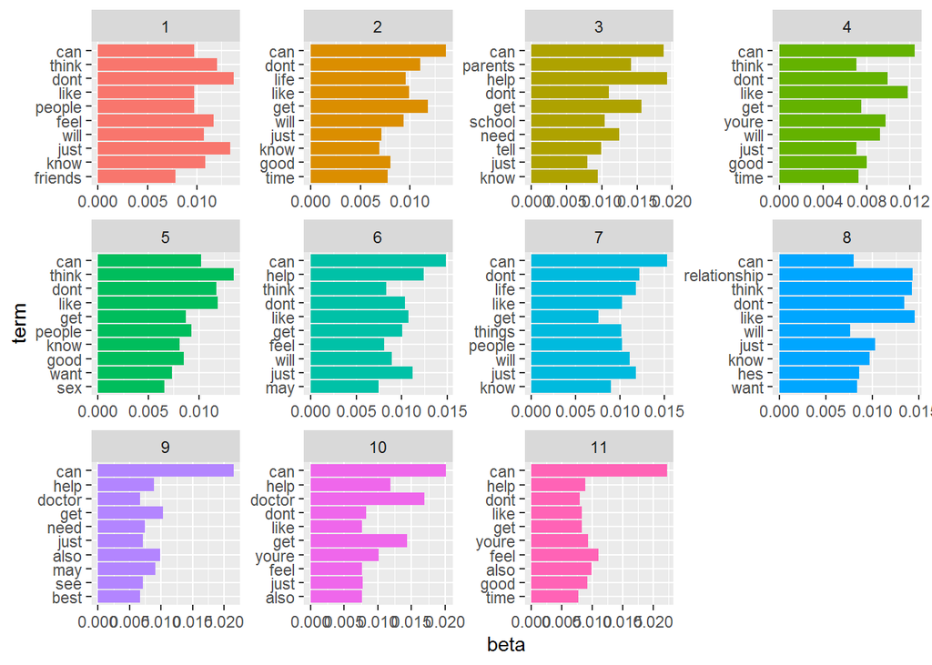

```r
top_terms <- lda_td %>%
  group_by(topic) %>%
  top_n(10, beta) %>%
  ungroup() %>%
  arrange(topic, -beta)

top_terms %>%
  mutate(term = reorder(term, beta)) %>%
  ggplot(aes(term, beta, fill = factor(topic))) +
  geom_bar(stat = "identity", show.legend = FALSE) +
  facet_wrap(~ topic, scales = "free") +
  coord_flip()
```

## K = 14. Paste your visualization in the space below:

```r
 lda <- LDA(dtm.new, k = 14)
lda_td <- tidy(lda)
lda_td
```

```
## # A tibble: 181,874 x 3
##    topic term             beta
##    <int> <chr>           <dbl>
##  1     1 actions 0.0000323
##  2     2 actions 0.00000000343
##  3     3 actions 0.000293
##  4     4 actions 0.0000000245
##  5     5 actions 0.000300
##  6     6 actions 0.000486
##  7     7 actions 0.000667
##  8     8 actions 0.000519
##  9     9 actions 0.0000876
## 10    10 actions 0.000359
## # ... with 181,864 more rows
```

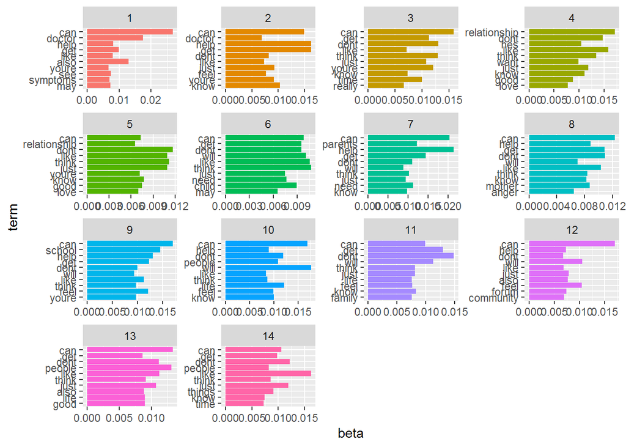

```r
top_terms <- lda_td %>%
  group_by(topic) %>%
  top_n(10, beta) %>%
  ungroup() %>%
  arrange(topic, -beta)

top_terms %>%
  mutate(term = reorder(term, beta)) %>%
  ggplot(aes(term, beta, fill = factor(topic))) +
  geom_bar(stat = "identity", show.legend = FALSE) +
  facet_wrap(~ topic, scales = "free") +
  coord_flip()
```

## 8. (20 points) Suppose that you are a researcher who works for National Institutes of Health (NIH). You are working on a project that aims to identify the most important reasons for mental disorders. Based on your analysis above, can we propose any hypothesis about the reasons for mental disorders in the society? Please explain.

*ANSWER: Analyzing and we could somehow say after hypertuning of our sentiment and topic modelling, we can draw some useful conclusion. From the visualization of word cloud with we can observe words like love, trust ,support, luck, smile, smart, sweet, are positive sentiment and words such as depress ,hate, bad ,hard stress , broke ,pain ,mad, represents negative sentiment. Even with topic modeling the both the columns the tops words in the topics include relationship, good, love , mom, people, school, friends etc*

*** So most of the mental disorders are related to the relationship as we saw many attributes like friends, mom, dad, people. Their stress or depression can also be main reasons for that. Generally, the society they are surrounded with and how they are treated by this comminity also reflected on our analysis.The main reason to mental disorder can also be human to human charectarisctics ***

*Therefore, maintaning good relationship, in other words the healthy one, with family, friends, and parents can bring positive impact on positive feelings like love, trust, and feel of support*